# Italian Attitudes Towards Government Contact Tracing During the COVID-19 Pandemic

Prof Simon Dennis$^1$, Dr Paul Garrett$^1$, Mr Joshua White$^1$, A/Prof Daniel Little$^1$, A/Prof Amy Perfors$^1$, Prof Yoshihisa Kashima$^1$, Prof Stephan Lewandowsky$^2$, Dr Andrea Guido$^3$, & Dr Giulia Andrighetto $^3$

$^1$Complex Human Data Hub, School of Psychological Sciences, The University of Melbourne.

$^2$School of Psychological Sciences, The University of Bristol.

$^3$Institute for Futures Studies, Stockholm, Sweden

28/07/2020

# Data Collection and Context

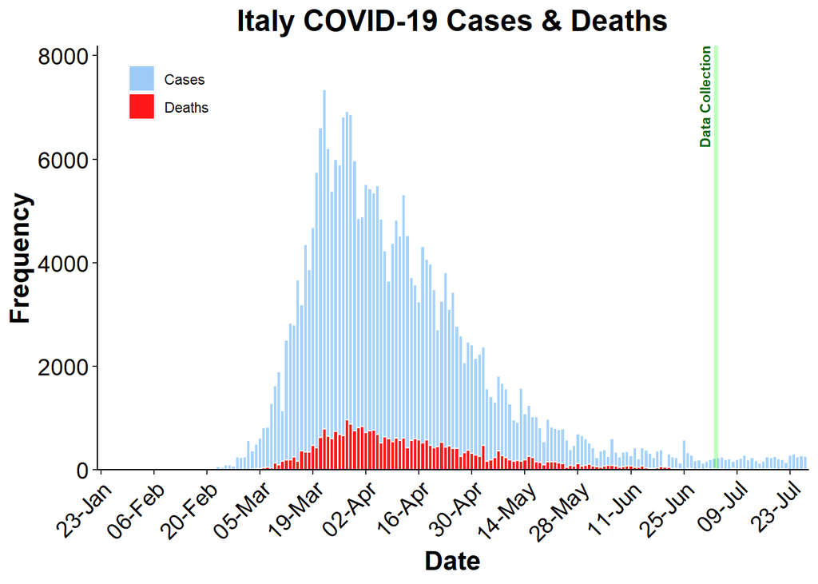

# Results

## Sample details

These results represent a snapshot from 505 participants collected during the second wave of the project, Establishing the social licence for Government tracking in Australia. This representative sample was gathered through the data collection platform Prolific.

Notes on cleaning the data.

1. Of the initial 505 participants collected, 9 participants did not pass the attention check.
2. 5 participants began and did not complete the survey.

After cleaning the data for the above participants, the final sample at analysis was 491 participants.

## Demographics

Our sample was strongly skewed towards younger Italians, and slightly skewed towards men. Below, we also show the distribution of the regions of residence of our participants.

| Gender identification: Percentages | Gender identification: Percentages #Total |
| --- | --- |
| Gender |  |
| Men | 56.6 |
| Women | 42.6 |
| Other | 0.4 |
| Prefer not to say | 0.4 |
| #Total cases | 491 |

| Level of education: Percentages | Level of education: Percentages #Total |
| --- | --- |
| Education |  |
| Did Not Graduate High School | 3.3 |
| Graduated High School | 52.5 |
| Graduated University | 44.2 |
| #Total cases | 491 |

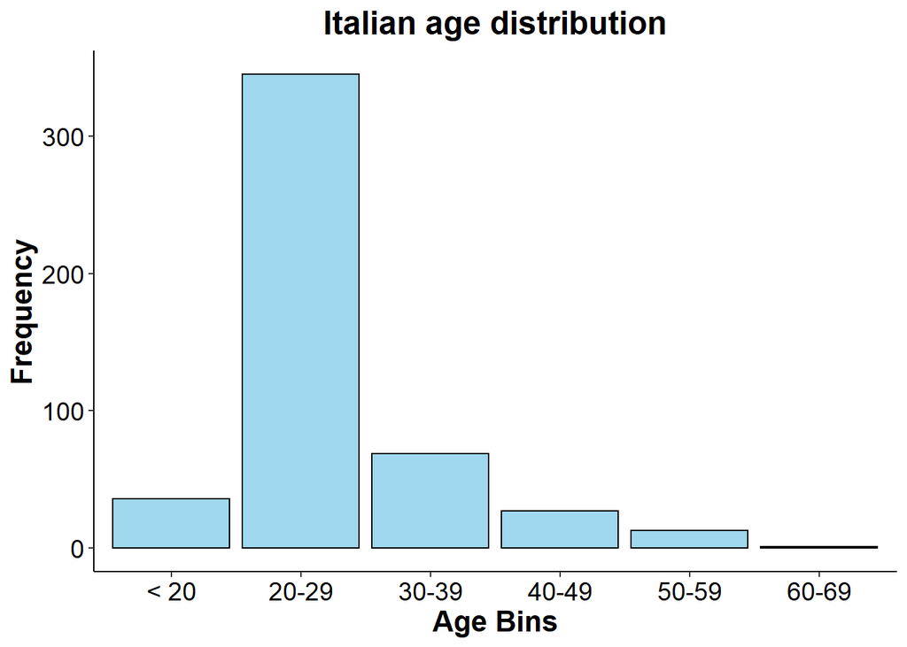

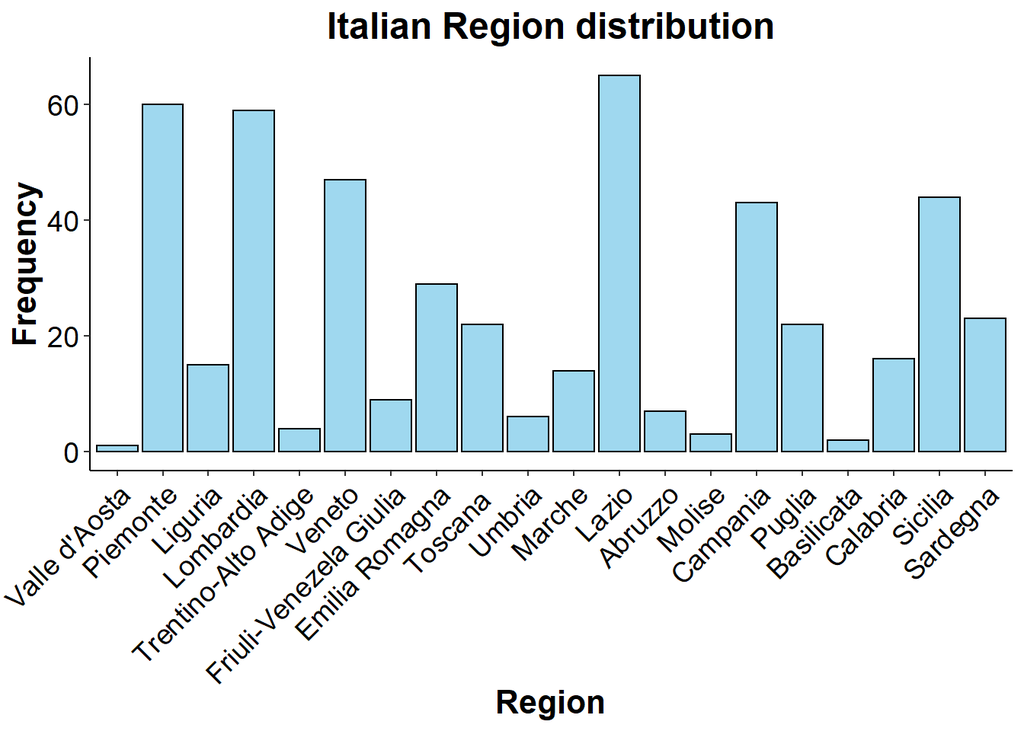

## Impacts of COVID

Our survey also asked participants about how they had experienced and been impacted by the COVID-19 pandemic.

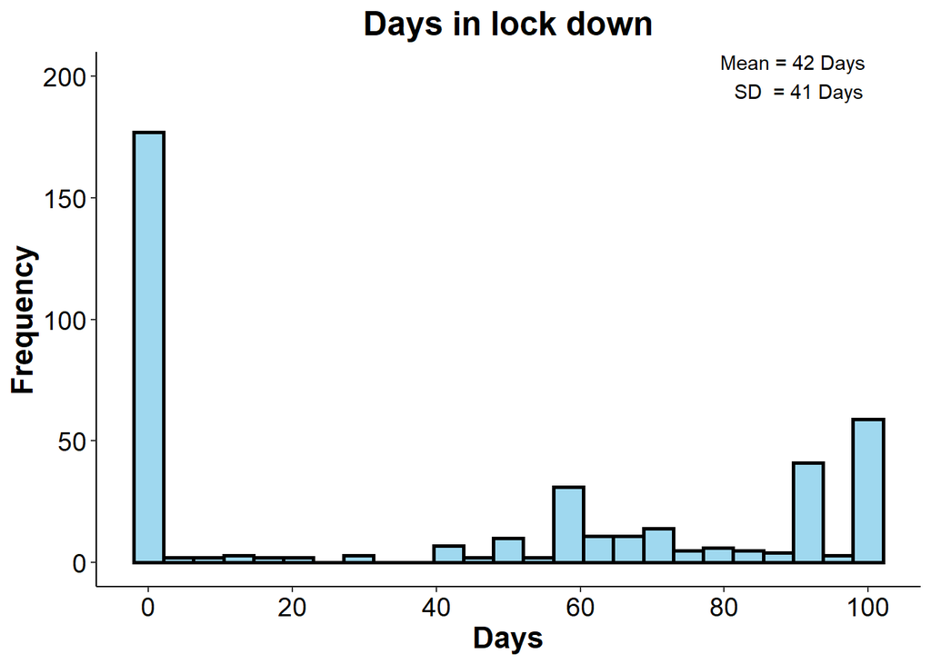

Further, approximately 18% of participants reporting losing their job, either in part or whole.

| I have lost my job: Percentages | I have lost my job: Percentages #Total |
| --- | --- |
| I lost my job |  |
| No | 82.3 |
| Yes | 17.7 |
| #Total cases | 491 |

A majority of people got their news regarding the COVID-19 pandemic from a Newspaper (44%), televisoin (27.5) and social media (22%).

| Information source: Percentages | Information source: Percentages #Total |
| --- | --- |
| Information source |  |
| Newspaper (printed or online) | 43.6 |
| Social media | 22.0 |
| Friends/family | 0.4 |
| Radio | 0.4 |
| Television | 27.5 |
| Other | 5.3 |
| Do not follow | 0.8 |
| #Total cases | 491 |

| Somebody I know tested positive for COVID-19: Percentages | Somebody I know tested positive for COVID-19: Percentages #Total |
| --- | --- |
| Tested pos someone I know |  |
| No | 56 |
| Yes | 44 |
| #Total cases | 491 |

[output not shown]

We asked participants to estimate what percentage of the general population were complying with government social distancing policies. The graph below shows that these estimates were quite varied (*SD* = 22%), with the mean estimate being 46%.

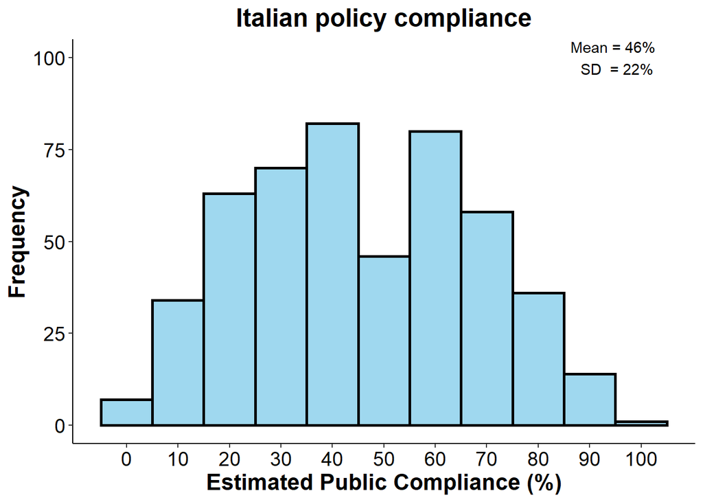

However, when asked to rate their own compliance with government social distancing policies,the picture was brighter with a clear majority of participants reported that they completely follow these policies, or go beyond them.

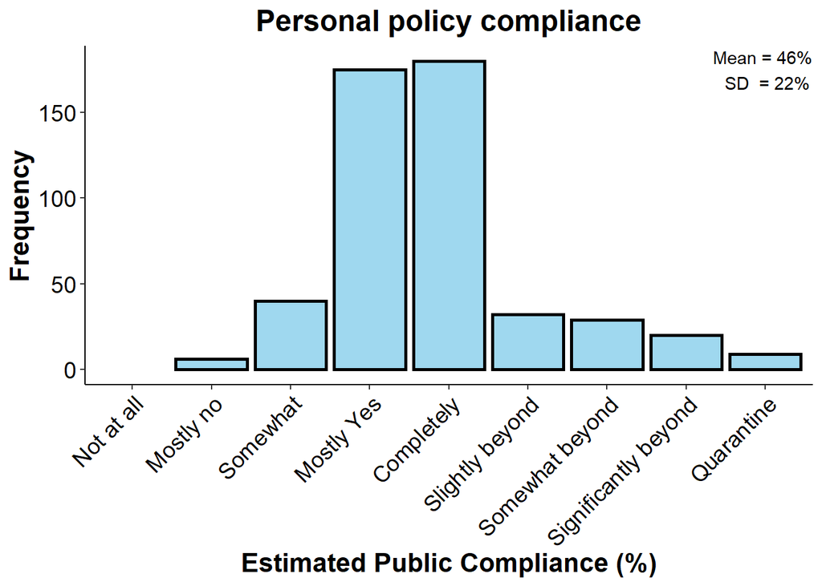

## Perceived Risk of COVID

Participants were asked four questions that asked them about their perceptions of the risk, and their worry about, the COVID pandemic.

1. How severe they believed the pandemic would be for the general population.
2. How severe they believed the pandemic would be for their personal health.
3. How concerned they are about contracting COVID-19.
4. How concerned are they about people they know contracing COVID-19.

The graph below shows participants responses to these questions.

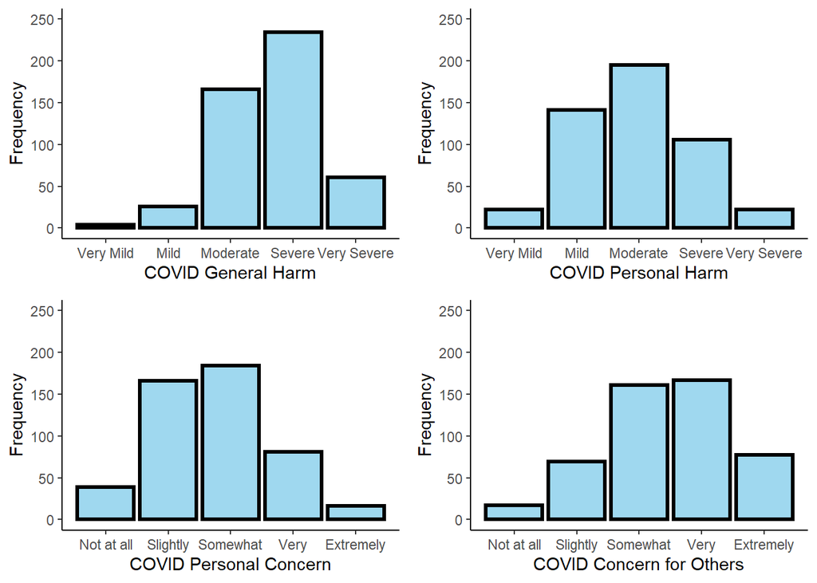

Finally, we asked participants to report their estimates on the number of fatalities across a range of countries with moderate-to-high media coverage in Australia. Responses were made on a sliding scale ranging from 0 - 120,000; results are reported in estimated deaths per 1000 (see violin plot).

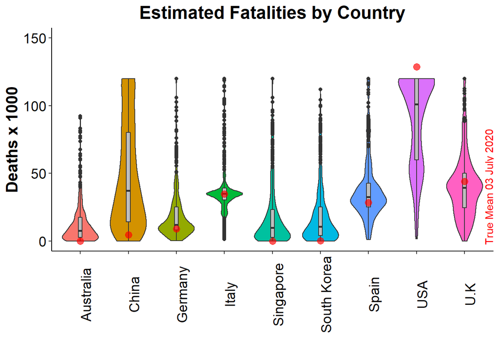

## Government Tracking App Scenario

Participants read the following scenario before answering questions abour their opinions of it:

The COVID-19 pandemic has rapidly become a worldwide threat. Containing the virus’ spread is essential to minimise the impact on the healthcare system, the economy, and save many lives. The Italian Government might consider using smartphone tracking data to identify and contact those who may have been exposed to people with COVID-19. This would help reduce community spread by identifying those most at risk and allowing health services to be appropriately targeted. **Only people that downloaded a government app and agreed to be tracked and contacted would be included in the project.** The more people that download and use this app the more effectively the Government would be able to contain the spread of COVID-19. Data would be stored in an encrypted format on a secure server accessible only to the Italian Government. **Data would only be used to contact those who might have been exposed to COVID-19.**

## Perceived Impact of Government Tracking App

The following boxplots characterize participant’s confidence that in each scenario Government tracking would:

1. Reduce their likelihood of contracting COVID-19
2. Allow them to resume their normal lives more rapidly
3. Reduce spread of COVID-19 in the community.
4. Be able to be used by people like oneself.

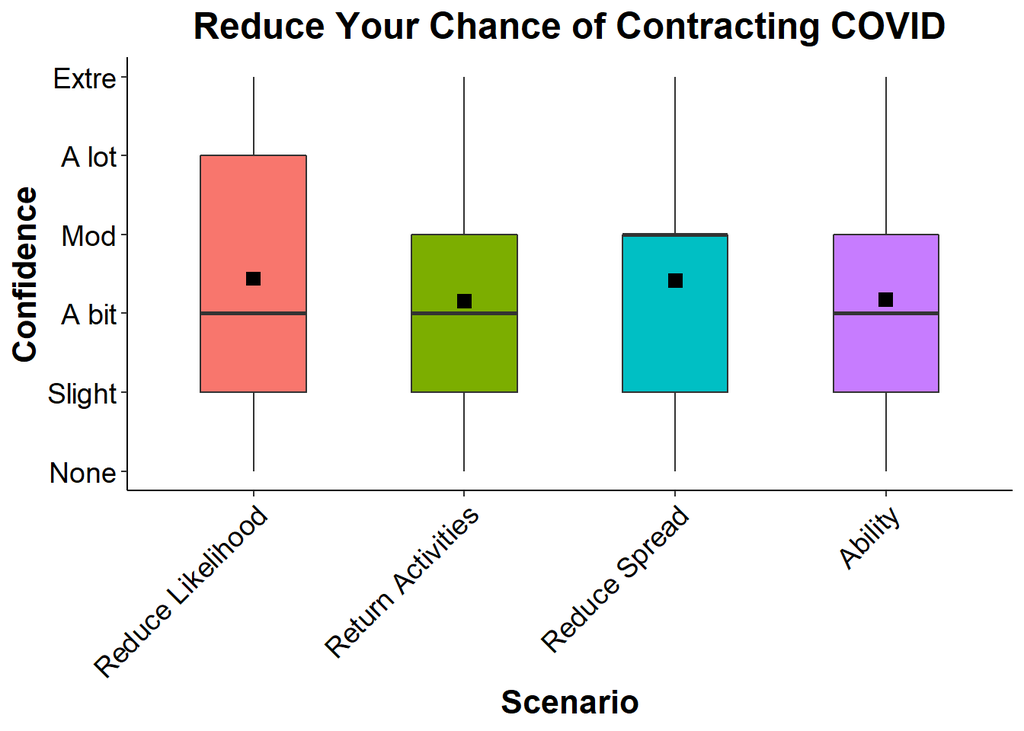

## Government Tracking app uptake

75% of our participants said they would download this app. After being asked questions about the privacy implications of the app (see below), this reduced slightly to 73%.

| Uptake of App: Percentages (before considering privacy implications) | Uptake of App: Percentages (before considering privacy implications) #Total |
| --- | --- |
| Would you download the app? |  |
| No | 25.3 |
| Yes | 74.7 |
| #Total cases | 491 |

| Uptake of App: Percentages (After considering privacy implications) | Uptake of App: Percentages (After considering privacy implications) #Total |
| --- | --- |
| Would you download the app? |  |
| No | 27.3 |
| Yes | 72.7 |
| #Total cases | 491 |

## Conditional Acceptance of Government Tracking

Participants who did previously answered that they would not download the app (134 participants), where then asked if they would do so if:

1. the Italian government promised that the app and data taken from it would only be used for 6-months, after which it would all be permanently deleted (i.e., a ‘sunset’); and
2. The data from the app was not stored on a central server but rather kept on the individuals phone.

31% of these participants said they would download the app if their was a 6-month sunset on the app, and 61% said they would download the app if the data was stored locally on their phone.

| Conditional uptake of App with 6-month sunset clause: Percentages | Conditional uptake of App with 6-month sunset clause: Percentages #Total |
| --- | --- |
| Would you download the app if all data was deleted after 6 months? |  |
| No | 68.7 |
| Yes | 31.3 |
| #Total cases | 134 |

| Conditional uptake of App with local storage: Percentages | Conditional uptake of App with local storage: Percentages #Total |
| --- | --- |
| Would you download the app if all data was stored locally on your phone? |  |
| No | 38.8 |
| Yes | 61.2 |
| #Total cases | 134 |

## Perceptions of the Privacy Implications of Government tracking

The next graph shows responses to the following items (abridged from survey):

1. How difficult is it for people to decline participation in the proposed project?
2. To what extent is the Government only collecting the data necessary?
3. How sensitive is the data being collected in the proposed project?
4. How serious is the risk of harm that could arise from the proposed project?
5. How much do you trust the Government to use the tracking data only to deal with the COVID-19 pandemic?
6. How much do you trust the Government to be able to ensure the privacy of each individual?
7. How secure is the data that would be collected for the proposed project?
8. To what extent do people have ongoing control of their data?

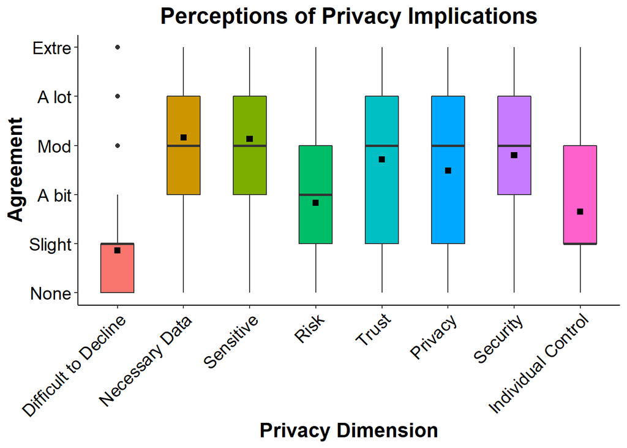